# final

This is the data for the League of Legends 2018 Spring split matches.

```r
dat <- read.csv("2018-spring-match-data-OraclesElixir-2018-05-02.csv", fileEncoding="UTF-8-BOM")
```

We will only be looking at the data for North America, NALCS.

```r
dat <- dat %>% filter(league == "NALCS")

dat[,"team"] <- as.character(dat[,"team"])
dat[,"team"] <- as.factor(dat[,"team"])

games <-
  dat %>%
  filter(position == "Team", side == "Blue") %>%
  nrow()
games
```

```
## [1] 117
```

We’ll do some cursory data analysis, then try to predict game outcomes.

We first examine the win rates for the two sides, blue and red. Historically blue side has had a higher win rate over red side, so we will expect to see the same now.

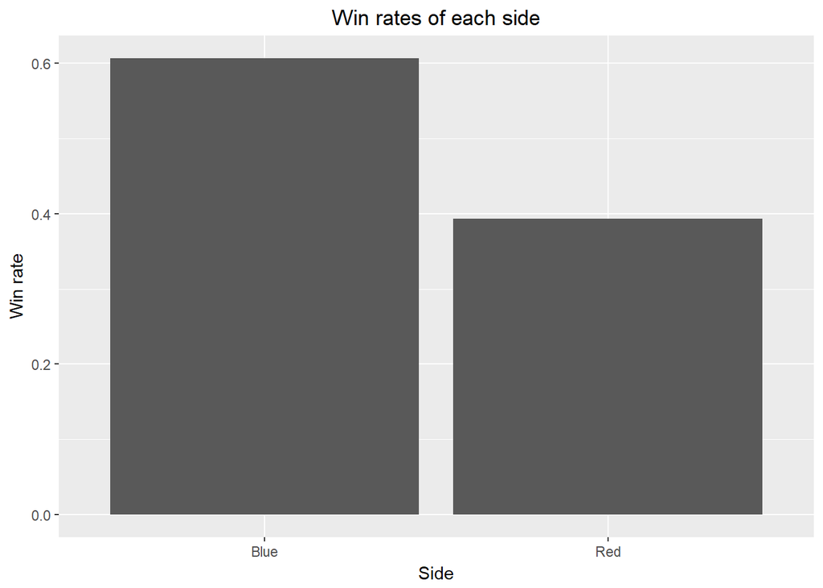

```r
dat %>%
  filter(position == "Team") %>%
  group_by(side) %>%
  summarize(wins = sum(result)) %>%
  mutate(winr = wins/117) %>%
  ggplot(aes(side, winr)) + geom_col() + xlab("Side") + ylab("Win rate") + ggtitle("Win rates of each side") + theme(plot.title = element_text(hjust = 0.5))
```

Blue side has a winrate of over 0.6, compared to red side’s 0.4

There have been different patches throughout the season as well. We examine how the game lengths have changed across the season.

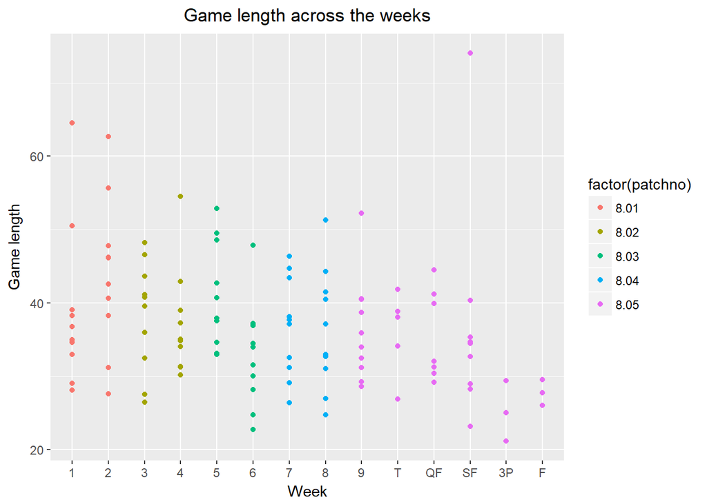

```r
dat %>%
  group_by(gameid) %>%
  ggplot(aes(factor(week, levels = c("1", "2", "3", "4", "5", "6", "7", "8", "9", "T", "QF", "SF", "3P", "F")), gamelength)) + geom_point(aes(color = factor(patchno))) + xlab("Week") + ylab("Game length") + ggtitle("Game length across the weeks") + theme(plot.title = element_text(hjust = 0.5))
```

We can see that the game length slightly decreases across the weeks.

Each team member on the team has a different amount of “carry potential”, which is the potential of them carrying the game given a gold lead. We want to investigate the differences in carry potential between the roles on each team. To do this we will fit a logistic regression model on the game result given the gold advantage at 15 minutes for each player.

```r
pos_dat <-
  dat %>%
  filter(position != "Team") %>%
  dplyr::select(gameid, result, position, gdat15) %>%
  gather(key, val, gdat15) %>%
  unite(key1, key, position) %>%
  spread(key1, val)
```

```r
carry_model <- glm(result~.-1, data=pos_dat %>% dplyr::select(-gameid), family=binomial)
carry_model %>%
  tidy() %>%
  knitr::kable(digits=4)
```

| term | estimate | std.error | statistic | p.value |
| --- | --- | --- | --- | --- |
| gdat15_ADC | 5e-04 | 2e-04 | 2.1893 | 0.0286 |
| gdat15_Jungle | 5e-04 | 3e-04 | 1.8650 | 0.0622 |
| gdat15_Middle | 4e-04 | 2e-04 | 1.7388 | 0.0821 |
| gdat15_Support | 4e-04 | 4e-04 | 1.0612 | 0.2886 |
| gdat15_Top | 2e-04 | 2e-04 | 0.8221 | 0.4110 |

We can clearly see from this model that the ADC has the most carry potential – if they have a gold lead at 15 minutes, the team is much more likely to win than if the Top or Support have a gold lead at 15. Interestingly, the Top lane has less carry potential than Support. This may be because support can build key utility items such as Redemption and Ardent Censer, whereas Top Lane mainly consists of tanks, who only need a couple tank items to be useful.

There was a big change in the jungle midway through the split that decreased their ability to place wards on the map. We expect to see a drop in wards for the junglers on all teams.

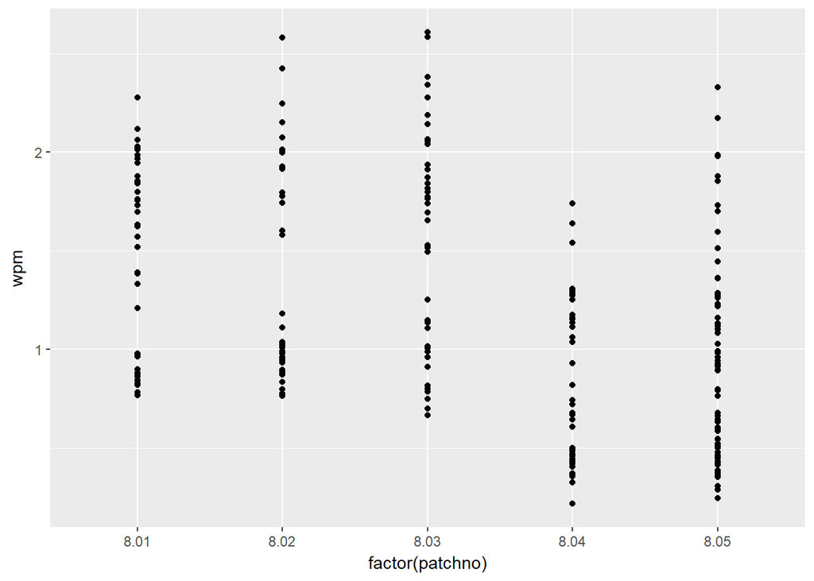

```r
dat %>%
  filter(position == "Jungle") %>%
  dplyr::select(patchno, wpm) %>%
  ggplot(aes(factor(patchno), wpm)) + geom_point()
```

We will try to predict game outcomes by predicting kills per side per game.

In League of Legends, kills are tracked and are a big part of the game, but they do not determine the game. The game is won by destroying the enemy team’s Nexus, which is a building in their base. Thus it is possible for the winning team to have less kills than the losing team. We want to determine how likely a team is to win given their KDA (kills, deaths, assists). To do this we will train a logistic regression classifier using the data from each team in each game.

```r
library(randomForest)
library(caret)
```

```r
set.seed(1234)

rf_dat <-
  dat %>%
  filter(position == "Team") %>%
  dplyr::select(result, k, d, a)

rf_dat$result <- as.factor(rf_dat$result)

#train_control <- trainControl(method="cv", number=10)

#model <- train(result~., data=rf_dat, method="glm", family="binomial", trControl=train_control)
kp_model <- glm(result~., data=rf_dat, family="binomial")

kp_model %>%
  tidy() %>%
  knitr::kable(digits=4)
```

| term | estimate | std.error | statistic | p.value |
| --- | --- | --- | --- | --- |
| (Intercept) | 0.1980 | 1.3394 | 0.1478 | 0.8825 |
| k | 0.7622 | 0.3278 | 2.3254 | 0.0201 |
| d | -0.8917 | 0.1865 | -4.7798 | 0.0000 |
| a | 0.0397 | 0.0875 | 0.4533 | 0.6503 |

We see that kills and deaths significantly predict game results, but assists don’t. This is to be expected, since a team that has few kills can still have many assists if each team member participated in the kill. However, assists give an essentially negligible amount of gold compared to a kill.

We want to examine the distribution of kills for each team.

```r
kills <-
  dat %>%
  filter(position == "Team") %>%
  dplyr::select(k)

summary(kills)
```

```
##        k
##  Min.   : 0.00
##  1st Qu.: 6.00
##  Median :10.00
##  Mean   : 9.88
##  3rd Qu.:14.00
##  Max.   :26.00
```

```r
sd(kills$k)^2
```

```
## [1] 27.53068
```

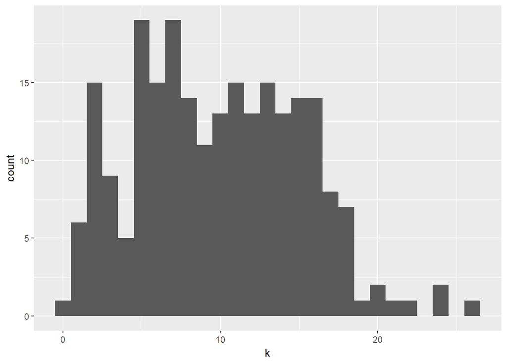

```r
kills %>%
  ggplot(aes(k)) + geom_histogram(binwidth = 1)
```

Since kills can be used to predict game results, we would like to predict kills in a game between particular teams. To model the kills by each side in a game, the first distribution that comes to mind is the poission distribution. However, the poission distribution models models rare events where the variance is equal to the mean, but for kills the variance does not the mean. In this case we will use the negative binomial distribution.

We will train this on the regular season data (Weeks 1 - 9) and test it on playoffs (T, QF, SF, 3P, F). We will only use data from before the match has started to predict, so we will use the team, opposition, and side.

```r
library(MASS)
```

```r
kills_dat <-
  dat %>%
  filter(position == "Team") %>%
  dplyr::select(gameid, side, team, k, week, result)
  #gather(key, val, team, k) %>%
  #unite(key1, key, side) %>%
  #spread(key1, val)

opp_teams <- matrix(NA, nrow(kills_dat),1)

for (i in seq(1, nrow(kills_dat))) {
  gameid <- kills_dat[i,]$gameid
  c_side <- kills_dat[i,]$side
  opp_team <- kills_dat[kills_dat$gameid == gameid & kills_dat$side != c_side,]$team
  kills_dat[i,"opp_team"] <- as.character(opp_team)
}

kills_dat[,"opp_team"] <- as.factor(kills_dat[,"opp_team"])

kills_dat_tr <-
  kills_dat %>%
  dplyr::select(-result) %>%
  filter(is.element(week, c(1, 2, 3, 4, 5, 6, 7, 8, 9)))

kills_dat_te <-
  kills_dat %>%
  dplyr::select(-result) %>%
  filter(is.element(week, c("T", "QF", "SF", "3P", "F")))
```

```r
kills_model <- glm.nb(k~team+side+opp_team, data=kills_dat_tr %>% dplyr::select(-week))
summary(kills_model)
```

```
##
## Call:
## glm.nb(formula = k ~ team + side + opp_team, data = kills_dat_tr %>%
##     dplyr::select(-week), init.theta = 6.630898432, link = log)
##
## Deviance Residuals:
##     Min       1Q   Median       3Q      Max
## -2.9496  -0.8386  -0.1171   0.6871   2.0295
##
## Coefficients:
##                              Estimate Std. Error z value Pr(>|z|)
## (Intercept)                   2.16622    0.18022  12.020   <2e-16 ***
## teamCloud9                    0.19465    0.16744   1.163   0.2450
## teamClutch Gaming            -0.09357    0.17117  -0.547   0.5846
## teamCounter Logic Gaming      0.10774    0.16862   0.639   0.5229
## teamEcho Fox                  0.35607    0.16528   2.154   0.0312 *
## teamFlyQuest                 -0.06895    0.17254  -0.400   0.6894
## teamGolden Guardians         -0.07319    0.17219  -0.425   0.6708
## teamOpTic Gaming             -0.11176    0.17262  -0.647   0.5173
## teamTeam Liquid               0.01789    0.17007   0.105   0.9162
## teamTeam SoloMid              0.10205    0.16918   0.603   0.5464
## sideRed                      -0.18341    0.07671  -2.391   0.0168 *
## opp_teamCloud9                0.24931    0.17161   1.453   0.1463
## opp_teamClutch Gaming        -0.20997    0.17952  -1.170   0.2421
## opp_teamCounter Logic Gaming  0.37289    0.16954   2.199   0.0278 *
## opp_teamEcho Fox              0.28432    0.17136   1.659   0.0971 .
## opp_teamFlyQuest              0.34790    0.16984   2.048   0.0405 *
## opp_teamGolden Guardians      0.37647    0.16924   2.224   0.0261 *
## opp_teamOpTic Gaming          0.25235    0.17094   1.476   0.1399
## opp_teamTeam Liquid          -0.07546    0.17699  -0.426   0.6698
## opp_teamTeam SoloMid         -0.09351    0.17779  -0.526   0.5989
## ---
## Signif. codes:  0 '***' 0.001 '**' 0.01 '*' 0.05 '.' 0.1 ' ' 1
##
## (Dispersion parameter for Negative Binomial(6.6309) family taken to be 1)
##
##     Null deviance: 245.67  on 179  degrees of freedom
## Residual deviance: 199.09  on 160  degrees of freedom
## AIC: 1111.1
##
## Number of Fisher Scoring iterations: 1
##
##
##               Theta:  6.63
##           Std. Err.:  1.27
##
##  2 x log-likelihood:  -1069.139
```

```r
predict(kills_model, newdata=data.frame(side="Blue", team="Team Liquid", opp_team="100 Thieves"))
```

```
##        1
## 2.184113
```

```r
predict(kills_model, newdata=data.frame(side="Blue", team="Echo Fox", opp_team="OpTic Gaming"))
```

```
##        1
## 2.774648
```

```r
predict(kills_model, newdata=data.frame(side="Red", team="OpTic Gaming", opp_team="Clutch Gaming"))
```

```
##        1
## 1.661071
```

However, we see that all predicted values for the kills are extremely small – they end to range between 1 and 3. Thus the negative binomial model was not successful at predicting kills per game.

```r
kills_dat_te %>%
  mutate(pred_k = predict(kills_model, newdata=kills_dat_te)) %>%
  mutate(error = (k - pred_k)^2)
```

```
##        gameid side          team  k week      opp_team   pred_k
## 1  1002510099 Blue   100 Thieves 16    T      Echo Fox 2.450541
## 2  1002510099  Red      Echo Fox  7    T   100 Thieves 2.338884
## 3  1002510106 Blue   Team Liquid 10    T        Cloud9 2.433421
## 4  1002510106  Red        Cloud9  5    T   Team Liquid 2.101994
## 5  1002510113 Blue  Team SoloMid 11    T Clutch Gaming 2.058298
## 6  1002510113  Red Clutch Gaming  5    T  Team SoloMid 1.795728
## 7  1002510123 Blue   Team Liquid  6    T  Team SoloMid 2.090606
## 8  1002510123  Red  Team SoloMid 17    T   Team Liquid 2.009395
## 9  1002510129 Blue        Cloud9 13    T Clutch Gaming 2.150898
## 10 1002510129  Red Clutch Gaming  5    T        Cloud9 2.138543
## 11 1002510203 Blue   Team Liquid  7   QF        Cloud9 2.433421
## 12 1002510203  Red        Cloud9  6   QF   Team Liquid 2.101994
## 13 1002510212 Blue        Cloud9  7   QF   Team Liquid 2.285407
## 14 1002510212  Red   Team Liquid 13   QF        Cloud9 2.250007
```

[output cut: 95 more lines]

We will try to use a gaussian distribution instead. A lognormal distribution is most likely not necessary since it is very unlikely for the model to predict a negative value, and the model also cannot predict 0.

```r
kills_model2 <- glm(k~team+side+opp_team, data=kills_dat_tr %>% dplyr::select(-week), family=gaussian)
summary(kills_model2)
```

```
##
## Call:
## glm(formula = k ~ team + side + opp_team, family = gaussian,
##     data = kills_dat_tr %>% dplyr::select(-week))
##
## Deviance Residuals:
##     Min       1Q   Median       3Q      Max
## -9.9954  -3.5962  -0.6169   3.4178  13.0549
##
## Coefficients:
##                              Estimate Std. Error t value Pr(>|t|)
## (Intercept)                    8.5514     1.7350   4.929 2.05e-06 ***
## teamCloud9                     2.1529     1.6576   1.299   0.1959
## teamClutch Gaming             -0.7471     1.6576  -0.451   0.6528
## teamCounter Logic Gaming       1.2311     1.6555   0.744   0.4582
## teamEcho Fox                   3.9092     1.6576   2.358   0.0196 *
## teamFlyQuest                  -0.3815     1.6605  -0.230   0.8186
## teamGolden Guardians          -0.4471     1.6576  -0.270   0.7877
## teamOpTic Gaming              -0.6908     1.6576  -0.417   0.6774
## teamTeam Liquid                0.1747     1.6605   0.105   0.9163
## teamTeam SoloMid               1.2028     1.6643   0.723   0.4709
## sideRed                       -1.5611     0.7484  -2.086   0.0386 *
## opp_teamCloud9                 2.5346     1.6576   1.529   0.1282
## opp_teamClutch Gaming         -1.5654     1.6576  -0.944   0.3464
## opp_teamCounter Logic Gaming   3.5189     1.6555   2.126   0.0351 *
## opp_teamEcho Fox               2.8408     1.6576   1.714   0.0885 .
## opp_teamFlyQuest               3.4440     1.6605   2.074   0.0397 *
## opp_teamGolden Guardians       3.6346     1.6576   2.193   0.0298 *
## opp_teamOpTic Gaming           2.4408     1.6576   1.473   0.1428
## opp_teamTeam Liquid           -0.5497     1.6605  -0.331   0.7410
## opp_teamTeam SoloMid          -0.5778     1.6643  -0.347   0.7289
## ---
## Signif. codes:  0 '***' 0.001 '**' 0.01 '*' 0.05 '.' 0.1 ' ' 1
##
## (Dispersion parameter for gaussian family taken to be 24.3111)
##
##     Null deviance: 4980.9  on 179  degrees of freedom
## Residual deviance: 3889.8  on 160  degrees of freedom
## AIC: 1106
##
## Number of Fisher Scoring iterations: 2
```

```r
predict(kills_model2, newdata=data.frame(side="Blue", team="Team Liquid", opp_team="100 Thieves"))
```

```
##        1
## 8.726075
```

```r
predict(kills_model2, newdata=data.frame(side="Blue", team="Echo Fox", opp_team="OpTic Gaming"))
```

```
##        1
## 14.90136
```

```r
predict(kills_model2, newdata=data.frame(side="Red", team="OpTic Gaming", opp_team="Clutch Gaming"))
```

```
##        1
## 4.734053
```

```r
kills_dat_te %>%
  mutate(pred_k = predict(kills_model2, newdata=kills_dat_te)) %>%
  mutate(error = (k - pred_k)^2)
```

```
##        gameid side          team  k week      opp_team    pred_k
## 1  1002510099 Blue   100 Thieves 16    T      Echo Fox 11.392204
## 2  1002510099  Red      Echo Fox  7    T   100 Thieves 10.899462
## 3  1002510106 Blue   Team Liquid 10    T        Cloud9 11.260666
## 4  1002510106  Red        Cloud9  5    T   Team Liquid  8.593500
## 5  1002510113 Blue  Team SoloMid 11    T Clutch Gaming  8.188719
## 6  1002510113  Red Clutch Gaming  5    T  Team SoloMid  5.665447
## 7  1002510123 Blue   Team Liquid  6    T  Team SoloMid  8.148310
## 8  1002510123  Red  Team SoloMid 17    T   Team Liquid  7.643356
## 9  1002510129 Blue        Cloud9 13    T Clutch Gaming  9.138863
## 10 1002510129  Red Clutch Gaming  5    T        Cloud9  8.777803
## 11 1002510203 Blue   Team Liquid  7   QF        Cloud9 11.260666
## 12 1002510203  Red        Cloud9  6   QF   Team Liquid  8.593500
## 13 1002510212 Blue        Cloud9  7   QF   Team Liquid 10.154560
## 14 1002510212  Red   Team Liquid 13   QF        Cloud9  9.699606
```

[output cut: 95 more lines]

We see that this model is much better at predicting kills than the previous.

Let’s try to use the models to predict playoffs wins.

```r
playoffs_dat <-
  kills_dat %>%
  filter(is.element(week, c("T", "QF", "SF", "3P", "F")))

pred_results <-
  playoffs_dat %>%
  mutate(pred_k = predict(kills_model, newdata=playoffs_dat)) %>%
  dplyr::select(-opp_team) %>%
  #mutate(error = (k - pred_k)^2) %>%
  gather(key, val, team, k, pred_k, result) %>%
  unite(key1, key, side) %>%
  spread(key1, val) %>%
  mutate(winner = ifelse(result_Blue == 1, team_Blue, team_Red)) %>%
  dplyr::select(-result_Blue, -result_Red) %>%
  mutate(pred_winner = ifelse(pred_k_Blue >= pred_k_Red, team_Blue, team_Red)) %>%
  mutate(correct = ifelse(winner == pred_winner, 1, 0))
sum(pred_results$correct) / nrow(pred_results)
```

```
## [1] 0.6666667
```

```r
playoffs_dat <-
  kills_dat %>%
  filter(is.element(week, c("T", "QF", "SF", "3P", "F")))

pred_results2 <-
  playoffs_dat %>%
  mutate(pred_k = predict(kills_model2, newdata=playoffs_dat)) %>%
  dplyr::select(-opp_team) %>%
  #mutate(error = (k - pred_k)^2) %>%
  gather(key, val, team, k, pred_k, result) %>%
  unite(key1, key, side) %>%
  spread(key1, val) %>%
  mutate(winner = ifelse(result_Blue == 1, team_Blue, team_Red)) %>%
  dplyr::select(-result_Blue, -result_Red) %>%
  mutate(pred_winner = ifelse(pred_k_Blue >= pred_k_Red, team_Blue, team_Red)) %>%
  mutate(correct = ifelse(winner == pred_winner, 1, 0))
sum(pred_results2$correct) / nrow(pred_results2)
```

```
## [1] 0.5555556
```

Interestingly, the negative binomial model is more accurate than the gaussian one despite having a high error rate. However, this test is extremely inaccurate because of the small amount of testing data.

Data is also very limited for training this model. Given more data (more splits), we can try to incorporate champions picked into the model to more accurately predict the result.

A better distribution to model the kills may also be helpful, since negative binomial and gaussian do not seem to be very accurate.